# ExtraaLearn Project

## Context

The EdTech industry has been surging in the past decade immensely, and according to a forecast, the Online Education market would be worth $286.62bn by 2023 with a compound annual growth rate (CAGR) of 10.26% from 2018 to 2023. The modern era of online education has enforced a lot in its growth and expansion beyond any limit. Due to having many dominant features like ease of information sharing, personalized learning experience, transparency of assessment, etc, it is now preferable to traditional education.

In the present scenario due to the Covid-19, the online education sector has witnessed rapid growth and is attracting a lot of new customers. Due to this rapid growth, many new companies have emerged in this industry. With the availability and ease of use of digital marketing resources, companies can reach out to a wider audience with their offerings. The customers who show interest in these offerings are termed as leads. There are various sources of obtaining leads for Edtech companies, like

- The customer interacts with the marketing front on social media or other online platforms.
- The customer browses the website/app and downloads the brochure
- The customer connects through emails for more information.

The company then nurtures these leads and tries to convert them to paid customers. For this, the representative from the organization connects with the lead on call or through email to share further details.

## Objective

ExtraaLearn is an initial stage startup that offers programs on cutting-edge technologies to students and professionals to help them upskill/reskill. With a large number of leads being generated on a regular basis, one of the issues faced by ExtraaLearn is to identify which of the leads are more likely to convert so that they can allocate resources accordingly. You, as a data scientist at ExtraaLearn, have been provided the leads data to:

- Analyze and build an ML model to help identify which leads are more likely to convert to paid customers,
- Find the factors driving the lead conversion process
- Create a profile of the leads which are likely to convert

## Data Description

The data contains the different attributes of leads and their interaction details with ExtraaLearn. The detailed data dictionary is given below.

**Data Dictionary**

- ID: ID of the lead
- age: Age of the lead
- current_occupation: Current occupation of the lead. Values include 'Professional','Unemployed',and 'Student'
- first_interaction: How did the lead first interacted with ExtraaLearn. Values include 'Website', 'Mobile App'
- profile_completed: What percentage of profile has been filled by the lead on the website/mobile app. Values include Low - (0-50%), Medium - (50-75%), High (75-100%)
- website_visits: How many times has a lead visited the website
- time_spent_on_website: Total time spent on the website
- page_views_per_visit: Average number of pages on the website viewed during the visits.
- last_activity: Last interaction between the lead and ExtraaLearn.
  - Email Activity: Seeking for details about program through email, Representative shared information with lead like brochure of program , etc
  - Phone Activity: Had a Phone Conversation with representative, Had conversation over SMS with representative, etc
  - Website Activity: Interacted on live chat with representative, Updated profile on website, etc
- print_media_type1: Flag indicating whether the lead had seen the ad of ExtraaLearn in the Newspaper.
- print_media_type2: Flag indicating whether the lead had seen the ad of ExtraaLearn in the Magazine.
- digital_media: Flag indicating whether the lead had seen the ad of ExtraaLearn on the digital platforms.
- educational_channels: Flag indicating whether the lead had heard about ExtraaLearn in the education channels like online forums, discussion threads, educational websites, etc.
- referral: Flag indicating whether the lead had heard about ExtraaLearn through reference.
- status: Flag indicating whether the lead was converted to a paid customer or not.

## Importing necessary libraries and data

```python
#mount the google drive account
from google.colab import drive
drive.mount('/content/drive')

#load dataset
import pandas as pd
df = pd.read_csv('/content/drive/MyDrive/ExtraaLearn.csv')
df.head() #shows the first five rows
```

|  | ID | age | current_occupation | first_interaction | profile_completed | website_visits | time_spent_on_website | page_views_per_visit | last_activity | print_media_type1 | print_media_type2 | digital_media | educational_channels | referral | status |
| --- | --- | --- | --- | --- | --- | --- | --- | --- | --- | --- | --- | --- | --- | --- | --- |
| 0 | EXT001 | 57 | Unemployed | Website | High | 7 | 1639 | 1.861 | Website Activity | Yes | No | Yes | No | No | 1 |
| 1 | EXT002 | 56 | Professional | Mobile App | Medium | 2 | 83 | 0.320 | Website Activity | No | No | No | Yes | No | 0 |
| 2 | EXT003 | 52 | Professional | Website | Medium | 3 | 330 | 0.074 | Website Activity | No | No | Yes | No | No | 0 |
| 3 | EXT004 | 53 | Unemployed | Website | High | 4 | 464 | 2.057 | Website Activity | No | No | No | No | No | 1 |
| 4 | EXT005 | 23 | Student | Website | High | 4 | 600 | 16.914 | Email Activity | No | No | No | No | No | 0 |

## Data Overview

- Observations
- Sanity checks

```python
#Let's take a quick look at the dimensions of this dataset
df.shape

#Before we start, let us also check for any missing values within the dataset
df.isnull().sum()

#Let's also do a couple sanity checks for the age, profile_completed, current_occupation, and status columns
print(f"Lowest age: {df['age'].min()} Highest age: {df['age'].max()}")
print(f"Lowest profile_completed: {df['profile_completed'].min()} Highest profile_completed: {df['profile_completed'].max()}")
print(df['current_occupation'].value_counts())
print(df['status'].value_counts())

#After running the code, the overall data looks reasonable. There seeems to be no major issues based on our sanity checks and observations.
```

```
Lowest age: 18 Highest age: 63
Lowest profile_completed: High Highest profile_completed: Medium
current_occupation
Professional    2616
Unemployed      1441
Student          555
Name: count, dtype: int64
status
0    3235
1    1377
Name: count, dtype: int64
```

## Exploratory Data Analysis (EDA)

- EDA is an important part of any project involving data.
- It is important to investigate and understand the data better before building a model with it.
- A few questions have been mentioned below which will help you approach the analysis in the right manner and generate insights from the data.
- A thorough analysis of the data, in addition to the questions mentioned below, should be done.

**Questions**

1. Leads will have different expectations from the outcome of the course and the current occupation may play a key role in getting them to participate in the program. Find out how current occupation affects lead status.
2. The company's first impression on the customer must have an impact. Do the first channels of interaction have an impact on the lead status?
3. The company uses multiple modes to interact with prospects. Which way of interaction works best?
4. The company gets leads from various channels such as print media, digital media, referrals, etc. Which of these channels have the highest lead conversion rate?
5. People browsing the website or mobile application are generally required to create a profile by sharing their personal data before they can access additional information.Does having more details about a prospect increase the chances of conversion?

## Data Preprocessing

- Missing value treatment (if needed)
- Feature engineering (if needed)
- Outlier detection and treatment (if needed)
- Preparing data for modeling
- Any other preprocessing steps (if needed)

```python
# Drop non-numeric columns that are irrelevant for modeling (e.g., 'ID' and other string columns)
df_encoded = df.drop(['ID', 'first_interaction', 'print_media_type1', 'print_media_type2',
                      'digital_media', 'educational_channels', 'referral'], axis=1)

# Perform one-hot encoding for remaining categorical columns if needed
df_encoded = pd.get_dummies(df_encoded, drop_first=True)

# Now let's check the data types again to ensure all are numeric
print(df_encoded.dtypes)

# Now let's check for any duplicate rows
duplicate_rows = df_encoded[df_encoded.duplicated()]
print(f"Number of duplicate rows: {duplicate_rows.shape[0]}")

# Initialize SMOTE for handling class imbalance
from imblearn.over_sampling import SMOTE
from collections import Counter

X = df_encoded.drop('status', axis=1)
y = df_encoded['status']

smote = SMOTE(random_state=7)

# Apply SMOTE to balance the dataset
X_balanced, y_balanced = smote.fit_resample(X, y)

# Check the new class distribution
print(f"Original class distribution: {Counter(y)}")
print(f"Balanced class distribution: {Counter(y_balanced)}")

# Let's import the libraries needed to perform the train test split for preprocessing
from sklearn.model_selection import train_test_split

# Split the balanced data into training and testing sets
X_train, X_test, y_train, y_test = train_test_split(X_balanced, y_balanced, test_size=0.3, random_state=7)

# Check the shape of the training and testing sets
print(f"Training shape: {X_train.shape}     Test shape: {X_test.shape}")


# Preview the first few rows of the balanced dataset
X_balanced.head()
```

```
age                                 int64
website_visits                      int64
time_spent_on_website               int64
page_views_per_visit              float64
status                              int64
current_occupation_Student           bool
current_occupation_Unemployed        bool
profile_completed_Low                bool
profile_completed_Medium             bool
last_activity_Phone Activity         bool
last_activity_Website Activity       bool
dtype: object
Number of duplicate rows: 48
Original class distribution: Counter({0: 3235, 1: 1377})
Balanced class distribution: Counter({1: 3235, 0: 3235})
Training shape: (4529, 10)     Test shape: (1941, 10)
```

|  | age | website_visits | time_spent_on_website | page_views_per_visit | current_occupation_Student | current_occupation_Unemployed | profile_completed_Low | profile_completed_Medium | last_activity_Phone Activity | last_activity_Website Activity |
| --- | --- | --- | --- | --- | --- | --- | --- | --- | --- | --- |
| 0 | 57 | 7 | 1639 | 1.861 | False | True | False | False | False | True |
| 1 | 56 | 2 | 83 | 0.320 | False | False | False | True | False | True |
| 2 | 52 | 3 | 330 | 0.074 | False | False | False | True | False | True |
| 3 | 53 | 4 | 464 | 2.057 | False | True | False | False | False | True |
| 4 | 23 | 4 | 600 | 16.914 | True | False | False | False | False | False |

## EDA

- It is a good idea to explore the data once again after manipulating it.

```
Balanced class distribution: Counter({1: 3235, 0: 3235})
```

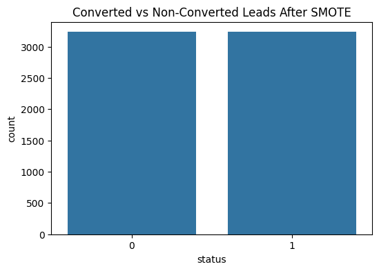

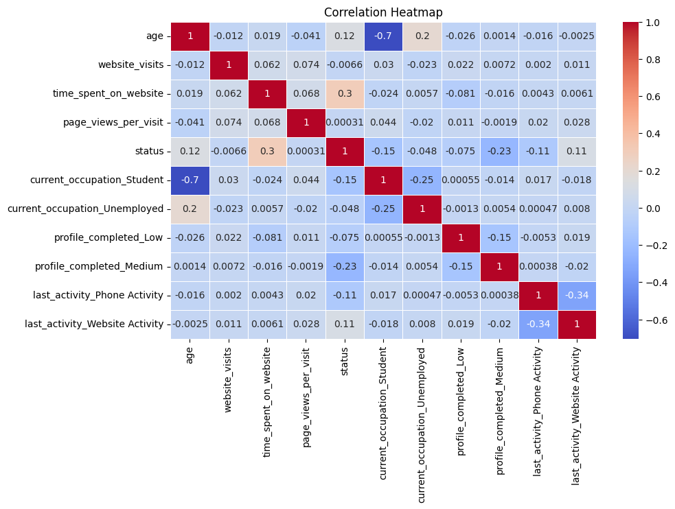

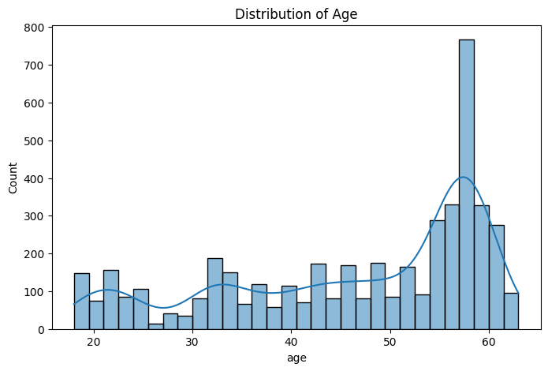

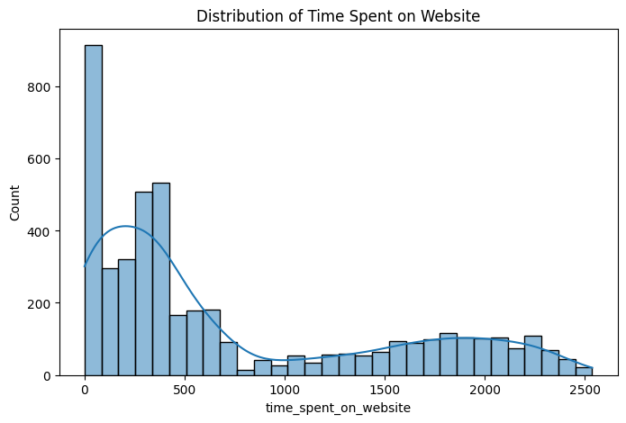

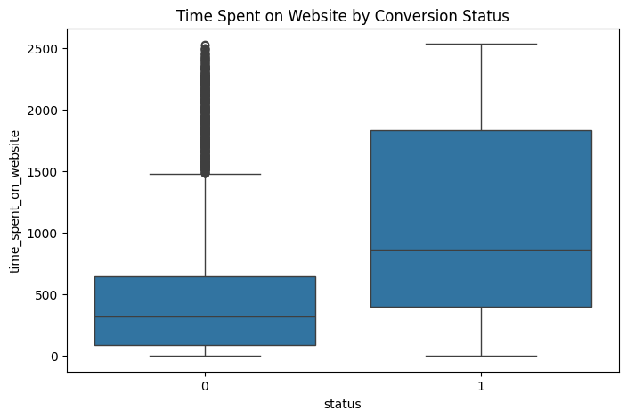

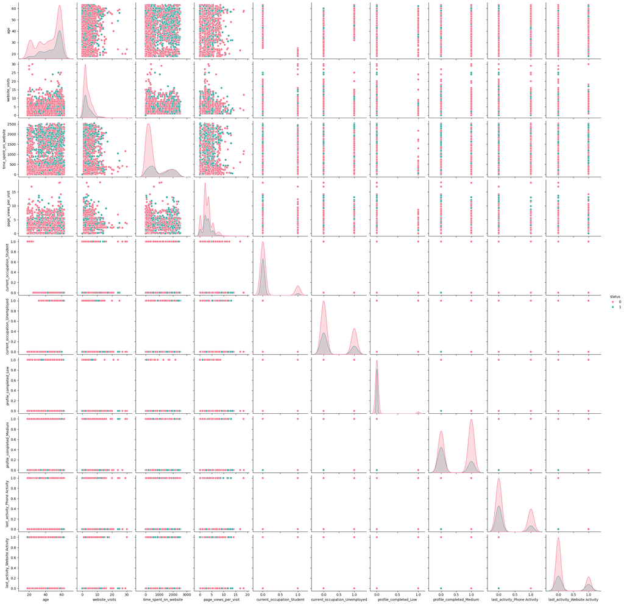

```python
import seaborn as sns
import matplotlib.pyplot as plt
from collections import Counter

# First we can check the balanced class distribution after SMOTE to make sure the values are even
print(f"Balanced class distribution: {Counter(y_balanced)}")

# Plot the balanced class distribution
plt.figure(figsize=(6,4))
sns.countplot(x=y_balanced)
plt.title('Converted vs Non-Converted Leads After SMOTE')
plt.show()

# Statistical summaries of numerical columns
df_encoded.describe()

# Correlation heatmap of numerical features
# 'annot' is particularly useful because it displays the values within each of the boxes for use to better understand the distribution of the values within the confusion matrix
plt.figure(figsize=(10,6))
sns.heatmap(df_encoded.corr(), annot=True, cmap='coolwarm', linewidths=0.5)
plt.title('Correlation Heatmap')
plt.show()

# Distribution of age
plt.figure(figsize=(8,5))
sns.histplot(df_encoded['age'], kde=True, bins=30)
plt.title('Distribution of Age')
plt.show()

# Distribution of time spent on the website
plt.figure(figsize=(8,5))
sns.histplot(df_encoded['time_spent_on_website'], kde=True, bins=30)
plt.title('Distribution of Time Spent on Website')
plt.show()

# Let's use a box plot to check the distribution of time spent on the website by conversion status
plt.figure(figsize=(8,5))
sns.boxplot(x=y_balanced, y=X_balanced['time_spent_on_website'])
plt.title('Time Spent on Website by Conversion Status')
plt.show()

# Let's use a pairplot to explore relationships between features
sns.pairplot(df_encoded, hue='status', diag_kind='kde', palette='husl')
plt.show()

#All these models can help us check our data one more time to see all the changes we made reflected onto these graphs
```

## Building a Decision Tree model

```
Accuracy: 0.7527047913446677
              precision    recall  f1-score   support

           0       0.74      0.75      0.74       939
           1       0.76      0.76      0.76      1002

    accuracy                           0.75      1941
   macro avg       0.75      0.75      0.75      1941
weighted avg       0.75      0.75      0.75      1941
```

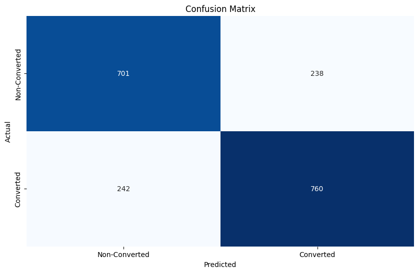

```python
# In order to make a decision tree model, we will need to import a few things.
from sklearn.tree import DecisionTreeClassifier
from sklearn.metrics import accuracy_score, classification_report, confusion_matrix
import matplotlib.pyplot as plt
import seaborn as sns

# First we will need to initialize the decision tree by creating the DecisionTreeClassifier object

tree_model = DecisionTreeClassifier(random_state=7)

# Next, we want to train the model based on our training data

tree_model.fit(X_train, y_train)

# Then, we will make predictions on the test data using the .predict() function

y_pred = tree_model.predict(X_test)

# Now let's evalute the model's performance

# Let's start with accuracy
accuracy = accuracy_score(y_test, y_pred)
print(f"Accuracy: {accuracy}")

# We can also print out the entire classification report to show us information about the precision, recall, and f1 score
print(classification_report(y_test, y_pred))

# Another way to check our model's performance is to take a look at the model's confusion matrix

matrix = confusion_matrix(y_test, y_pred)
plt.figure(figsize=(10,6))
# Using the heatmap function with annot=True, fmt='d', cbar=False, and all these expressions, we can make the matrix more readable
sns.heatmap(matrix, annot=True, fmt='d', cmap='Blues', cbar=False, xticklabels=['Non-Converted', 'Converted'], yticklabels=['Non-Converted', 'Converted'])
plt.xlabel('Predicted')
plt.ylabel('Actual')
plt.title('Confusion Matrix')
plt.show()

# This is not bad of an accuracy to start with so let us see in the next steps to see how we can improve this model.
```

## Do we need to prune the tree?

```
Tree Depth: 30
Number of Leaves: 879
Accuracy: 73.98%
Classification Report
              precision    recall  f1-score   support

           0       0.74      0.72      0.73       939
           1       0.74      0.76      0.75      1002

    accuracy                           0.74      1941
   macro avg       0.74      0.74      0.74      1941
weighted avg       0.74      0.74      0.74      1941
```

[figure not shown]

```python
# In order to determine whether or not we need to prune the tree, let us check the depth and number of leaves of the decision tree
tree_depth = tree_model.get_depth()
num_leaves = tree_model.get_n_leaves()

print(f"Tree Depth: {tree_depth}")
print(f"Number of Leaves: {num_leaves}")

# After running this first part, we will find that the tree depth is 30 with 879 leaves
# Since this tree is quite deep and complex, we can use pruning here to prevent overfitting and simplifying the model

# To prune a tree, let us first initialize a pruned decision tree model
pruned_tree = DecisionTreeClassifier(max_depth=5, random_state=7)

# Now let us train this model
pruned_tree.fit(X_train, y_train)

# Then, we will make predictions just like we did earlier above
y_pred_pruned = pruned_tree.predict(X_test)

# Now, we can perform the same evaluation tests as before to get a visualization of the model's performance
print(f"Accuracy: {accuracy_score(y_test, y_pred_pruned) * 100:.2f}%")
print("Classification Report")
print(classification_report(y_test, y_pred_pruned))

# Finally, we will make another confusion matrix for this pruned tree

pruned_matrix = confusion_matrix(y_test, y_pred)
plt.figure(figsize=(10,6))
sns.heatmap(pruned_matrix, annot=True, fmt='d', cmap='Blues', cbar=False, xticklabels=['Non-Converted', 'Converted'], yticklabels=['Non-Converted', 'Converted'])
plt.xlabel('Predicted')
plt.ylabel('Actual')
plt.title('Pruned Confusion Matrix')
plt.show()

# After reviewing and comparing the results of the original tree and the pruned tree, we can conclude that pruning was not necessary as it made the accuracy even lower
# The original tree had an accuracy at about .75 while the pruned tree had an accuracy of around .74.
# Not only was the original tree better at the accuracy, it also performed better in the f1 scores for both classes, showing us that pruning did not help
```

## Building a Random Forest model

```
Accuracy of Random Forest Model: 79.03%
Classification Report for Random Forest Model:
              precision    recall  f1-score   support

           0       0.80      0.75      0.78       939
           1       0.78      0.82      0.80      1002

    accuracy                           0.79      1941
   macro avg       0.79      0.79      0.79      1941
weighted avg       0.79      0.79      0.79      1941
```

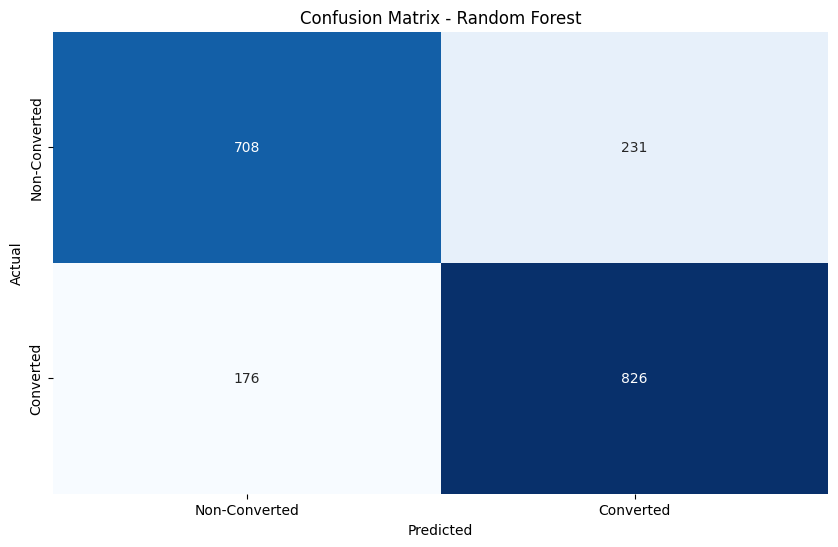

```python
# Let's first import the necessary libraries
from sklearn.ensemble import RandomForestClassifier
from sklearn.metrics import accuracy_score, classification_report, confusion_matrix
import seaborn as sns
import matplotlib.pyplot as plt

# First we will initialize the classifier
random_model = RandomForestClassifier(random_state=7, n_estimators=100)

# Then, we can train the model as usual
random_model.fit(X_train, y_train)

# Now we can make the predictions on the test data
y_pred_random = random_model.predict(X_test)

# Similar to the last couple times, we will perform some evaluations
random_accuracy = accuracy_score(y_test, y_pred_random)
print(f"Accuracy of Random Forest Model: {random_accuracy * 100:.2f}%")

# Classification report
print("Classification Report for Random Forest Model:")
print(classification_report(y_test, y_pred_random))

# Let's make the confusion matrix now
random_conf_matrix = confusion_matrix(y_test, y_pred_random)
plt.figure(figsize=(10,6))
sns.heatmap(random_conf_matrix, annot=True, fmt='d', cmap='Blues', cbar=False,
            xticklabels=['Non-Converted', 'Converted'],
            yticklabels=['Non-Converted', 'Converted'])
plt.xlabel('Predicted')
plt.ylabel('Actual')
plt.title('Confusion Matrix - Random Forest')
plt.show()

# From this one, we can see that there is a higher accuracy than the previous two models at an accuracy of .79 which is a good improvement.
```

## Do we need to prune the tree?

```python
# The answer is no. This is because forests have a special feature where they are made of multiple decision trees to make their predictions
# Pruning the individual trees within the forest is not necessary. Since there are many trees, they will average out and combine their predictions to give us a more consistent model
# So the final answer is no, because the overfitting issue is already taken care of by the multiple trees within the random forest which has good diversity
```

## Actionable Insights and Recommendations

Looking back at the entire project, we could tell that a random forest will be the best model. It demonstrates that ensemble methods will be better for reducing overfitting and improving accuracy. Overall, that means that for this problem, ensemble models like the random forest would be more desireable for predicting lead conversion.

Some recommendations is that we should focus marketing and engagement strategies on the most important features. For example, if profile completion is a key factor, we should consider adding incentives to encourage users to complete their profiles. Another one would be their time spend on the websites. If this correlates to the conversions, we should invest in improving the website engagement like making a better user interface and having good interactive content for the user to be attrated to the website.

Another key thing used within this project was the SMOTE. After finding that there was a class imbalance within the status category, we used the SMOTE method to help balance our data to ensure a non-biased training process to ensure the best results. ExtraaLearn should investigate the reasons for non-conversion by gathering feedback from the non-converted leads to understand the issues at hand.